# STAT 331 Portfolio

Author

Carson Freedman

**Learning Objective Evidence:** In the code chunks below, provide code from a Lab or Challenge assignment where you believe you have demonstrated proficiency with the specified learning target. Be sure to specify **where** the code came from (e.g., Lab 4 Question 2).

## Working with Data

**WD-1: I can import data from a *variety* of formats (e.g., csv, xlsx, txt, etc.).**

- `csv`

```r
# Lab 2, q1
surveys <- read_csv(file = here("Week2", "Lab2", "surveys.csv"))
```

- `xlsx`

```r
# Preview 2.2, q4
# Code to read in the ages.xlsx data goes here!
ages_xlsx = readxl::read_xlsx(here::here("Week2", "Preview", "Ages_Data", "ages.xlsx"))
```

- `txt`

```r
# Preview 2.2, q2
# Code to read in the ages_mystery.txt data goes here!
ages_mystery <- read_delim(here::here("Week2", "Preview", "Ages_Data",
                                      "ages_mystery.txt"), delim = "|")
```

**WD-2: I can select necessary columns from a dataset.**

```r
# Lab 3, q8
hiphop_clean |>
  select(subj, sex, age, ethnic) |>
  distinct(.keep_all = TRUE) |>
  subset(sex != "Female") |>
  subset(ethnic == "white") |>
  summary()
```

**WD-3: I can filter rows from a dataframe for a *variety* of data types (e.g., numeric, integer, character, factor, date).**

- numeric

```r
# Lab 3, q11
hiphop_clean |>
  mutate(familiarity = as.numeric(familiarity)) |>
  filter(age < 20) |>
  group_by(word) |>
  summarise(avg = mean(familiarity)) |>
  arrange(desc(avg))
```

- integer

```r
# Practice Activity 9.2, q3
tibble(val = my_weights) |>
  filter(val < 4532)
```

- character – specifically a string

```r
# Lab 3, q12
hiphop_clean |>
  mutate(familiarity = as.numeric(familiarity)) |>
  filter(sex == "Female" & ethnic == "non-white") |>
  group_by(word) |>
  summarise(avg = mean(familiarity)) |>
  arrange(desc(avg))
```

- factor

```r
# Lab 9, q8
names |>
  group_by(Name, Year) |>
  filter(Name %in% c("Allan", "Allen", "Alan")) |>
  summarize(Total = sum(Count)) |>
  ggplot(mapping = aes(x = Year, y = Total, fill = Name, color = Name)) +
  geom_col() +
  lims(x = c(1996, 2014))
```

- date

```r
# Practice 5, q3
thanksgiving <- mdy("November 22nd, 2018", tz = "America/Los_Angeles")
tg_interval <- (thanksgiving - days(35)) %--% (thanksgiving + days(35))

suspects <- suspects |>
  filter(Time.Spotted %within% tg_interval)
```

**WD-4: I can modify existing variables and create new variables in a dataframe for a *variety* of data types (e.g., numeric, integer, character, factor, date).**

- numeric

```r
# Lab 3, q12
hiphop_clean |>
  mutate(familiarity = as.numeric(familiarity)) |>
  filter(sex == "Female" & ethnic == "non-white") |>
  group_by(word) |>
  summarise(avg = mean(familiarity)) |>
  arrange(desc(avg))
```

- integer

```r
# Lab 9, q10
names |>
  filter(Name == "Allan" | Name == "Allen" | Name == "Alan", Year == 2000,
         State == "PA" | State == "CA") |>
  group_by(State) |>
  count(Name, wt = Count) |>
  mutate(prop = n / sum(n)) |>
  select(-n) |>
  pivot_wider(names_from = Name, values_from = prop)
```

- character – specifically a string

```r
# Lab 8, step 4
xmas2 <- xmas %>%
  mutate(Full.Phrase = pmap_chr(.l = list(Day, Day.in.Words, Gift.Item, Verb,
                                          Adjective, Location),
                                .f = make_phrase)
        )
```

- factor

```r
# Lab 5, part 2 q3
halfweek_captures <- surveys |>
  count(day_of_week) |>
  drop_na() |>
  mutate(
    day_of_week = fct_collapse(day_of_week,
                               "Weekday" = c("Mon", "Tue", "Wed", "Thu", "Fri"),
                               "Weekend" = c("Sat", "Sun")
    )
  )
```

- date

```r
# Practice 5, q6
epoch <- mdy("January 1st, 1970")
suspects |>
  mutate(diff = difftime(time1 = Time.Spotted, time2 = epoch, units = "mins"))
```

**WD-5: I can use mutating joins to combine multiple dataframes.**

```r
# Preview 4.3, q1
inner_join(prof_info, prof_course)
```

- `full_join()`

```r
# Preview 4.3, q2
full_join(prof_info, prof_course)
```

**WD-6: I can use filtering joins to filter rows from a dataframe.**

- `semi_join()`

```r
# Lab 4, q6
cali_remove <- tibble(region = c("LosAngeles", "SanDiego", "Sacramento",
                                  "SanFrancisco"))

diffs <- avocados |>
  semi_join(cali_remove) |>
  group_by(region, type, year) |>
  summarize(mean(AveragePrice))
```

- `anti_join()`

```r
# Lab 4, q2
regions <- tibble(region = c("West", "GreatLakes", "Midsouth", "Plains",
                             "SouthCentral", "Southeast", "TotalUS",
                             "NorthernNewEngland", "Northeast"))

avocados |>
  anti_join(regions) |> # remove regions with filtering join
  rename(location = region)
```

**WD-7: I can pivot dataframes from long to wide and visa versa**

- `pivot_longer()`

```r
# Practice 4, q4
pivoted <- military_clean |>
  pivot_longer(names_to = "Year", values_to = "Spending", .cols = -c(`Country`, `Notes`, `Reporting year`))
```

- `pivot_wider()`

```r
# Lab 4, q6
diffs |>
  group_by(region, type) |>
  summarize(price = mean(`mean(AveragePrice)`)) |>
  pivot_wider(names_from = type, values_from = price)
```

## Reproducibility

**R-1: I can create professional looking, reproducible analyses using RStudio projects, Quarto documents, and the here package.**

I’ve done this in the following provided assignments: Lab 2, Challenge 2, Lab 3, Challenge 3, Lab 5 (Revised)

**R-2: I can write well documented and tidy code.**

- Example 1
  - Named code chunks

````r
# Lab 2, q6
#```{r jitter}
ggplot(data = surveys, mapping = aes(x = weight, y = hindfoot_length)) +
  geom_jitter(alpha = 0.1, width = 0.2, height = 0.2) +
  labs(x = "Weight of Rodent (g)", y = "Rodent Hindfoot Length (mm)")
#```
````

- Example 2
  - Commented pipeline steps

```r
# Lab 3, q5
hiphop_clean <- hiphop |>
  # replace all NA values with zeroes
  mutate(across(.cols = numPreferredArtists:numOverallArtists,
                .fns = ~replace_na(., replace = 0)),
         # replace zeroes in city & county cols with NA
         across(.cols = city:county, .fns = ~na_if(x = ., y = 0)),
         # convert likert scores stored as nums to factors
         across(.cols = c("familiarity", "jayz", "barkley", "boondocks",
                          "monique", "bieber"), .fns = factor))
```

**R-3: I can write robust programs that are resistant to changes in inputs.**

- Example 1

```r
# Lab 7, q2
grouped_fish <- fish |>
  group_by(year, section, trip) |>
  summarize(across(everything(), ~ sum(is.na(.x))))
```

- Example 2

```r
# Lab 8, step 4
xmas2 <- xmas %>%
  mutate(Full.Phrase = pmap_chr(.l = list(Day, Day.in.Words, Gift.Item, Verb,
                                          Adjective, Location),
                                .f = make_phrase)
        )
```

## Data Visualization & Summarization

**DVS-1: I can create visualizations for a *variety* of variable types (e.g., numeric, character, factor, date)**

- numeric variables

```r
# Lab 2, q5
ggplot(data = surveys, mapping = aes(x = weight, y = hindfoot_length)) +
  geom_point(alpha = 0.1) +
  labs(x = "Weight of Rodent (g)", y = "Rodent Hindfoot Length (mm)")
```

- numeric variables and categorical variables

```r
# Challenge 2, q1 & q2
ggplot(data = surveys, mapping = aes(x = weight, y = species)) +
  geom_density_ridges(mapping = aes(color = genus, fill = genus)) +
  geom_jitter(size = 0.5, width = 0.1, height = 0.05, alpha = 0.15,
              color = "darkseagreen") +
  scale_color_viridis_d(option = "D", aesthetics = c("color", "fill")) +
  labs(title = "Weights of Various Rodent Species", x = "Rodent Weight (g)",
       y = "Species of Rodent", color = "Rodent Genus", fill = "Rodent Genus")
```

- categorical variables

```r
# Lab 3, q10
ggplot(data = hiphop_clean, mapping = aes(x = age, fill = ethnic)) +
  geom_bar() +
  labs(x = "Age of Participant", y = "Number of Responses", fill = "Ethnicity")
```

- dates

```r
# Lab 5, q2 (revised)
mean_weights <- surveys |>
  group_by(genus, date) |>
  summarize(weight = mean(weight))

ggplot(data = mean_weights, mapping = aes(x = date, y = weight,
                                          color = genus)) +
  geom_line() +
  theme_minimal() +
  labs(x = "Year", y = "", title = "Weight of Rodent by Species (g)")
```

**DVS-2: I use plot modifications to make my visualization clear to the reader.**

- Example 1

```r
# Challenge 2, q1 & q2
ggplot(data = surveys, mapping = aes(x = weight, y = species)) +
  geom_density_ridges(mapping = aes(color = genus, fill = genus)) +
  geom_jitter(size = 0.5, width = 0.1, height = 0.05, alpha = 0.15,
              color = "darkseagreen") +
  scale_color_viridis_d(option = "D", aesthetics = c("color", "fill")) +
  labs(title = "Weights of Various Rodent Species", x = "Rodent Weight (g)",
       y = "Species of Rodent", color = "Rodent Genus", fill = "Rodent Genus")
```

- Example 2

```r
# Challenge 7, q3
fish |>
  group_by(year, species) |>
  summarize(condition = mean(condition, na.rm = TRUE)) |>
  ggplot(mapping = aes(x = as.factor(year), y = condition)) +
  geom_point(position = "jitter", mapping = aes(fill = species, color = species)) +
  lims(y = c(0, 0.05)) +
  scale_fill_brewer(palette = "Paired") +
  labs(title = str_c("Condition of Blackfoot River Trout"),
      subtitle = str_c("by species:
                       <span style = 'color:#f8766d'>**Brown**</span>,
                       <span style = 'color:#00bfc4'>**Rainbow**</span>,
                       <span style = 'color:#7cae00'>**Bull**</span>,
                       <span style = 'color:#c77cff'>**WCT**</span>"
                      ),
      x = "Year of Observation",
      y = "",
    ) +
  theme(plot.title = element_markdown(size = 16),
        plot.subtitle = element_markdown(size = 12),
        legend.position = "none")
```

**DVS-3: I show creativity in my visualizations**

- Example 1

```r
# Challenge 2, q1 & q2
ggplot(data = surveys, mapping = aes(x = weight, y = species)) +
  geom_density_ridges(mapping = aes(color = genus, fill = genus)) +
  geom_jitter(size = 0.5, width = 0.1, height = 0.05, alpha = 0.15,
              color = "darkseagreen") +
  scale_color_viridis_d(option = "D", aesthetics = c("color", "fill")) +
  labs(title = "Weights of Various Rodent Species", x = "Rodent Weight (g)",
       y = "Species of Rodent", color = "Rodent Genus", fill = "Rodent Genus")
```

- Example 2

```r
# Challenge 7, q3
fish |>
  group_by(year, species) |>
  summarize(condition = mean(condition, na.rm = TRUE)) |>
  ggplot(mapping = aes(x = as.factor(year), y = condition)) +
  geom_point(position = "jitter", mapping = aes(fill = species, color = species)) +
  lims(y = c(0, 0.05)) +
  scale_fill_brewer(palette = "Paired") +
  labs(title = str_c("Condition of Blackfoot River Trout"),
      subtitle = str_c("by species:
                       <span style = 'color:#f8766d'>**Brown**</span>,
                       <span style = 'color:#00bfc4'>**Rainbow**</span>,
                       <span style = 'color:#7cae00'>**Bull**</span>,
                       <span style = 'color:#c77cff'>**WCT**</span>"
                      ),
      x = "Year of Observation",
      y = "",
    ) +
  theme(plot.title = element_markdown(size = 16),
        plot.subtitle = element_markdown(size = 12),
        legend.position = "none")
```

**DVS-4: I can calculate numerical summaries of variables.**

- Example 1

```r
# Lab 3, q12
hiphop_clean |>
  mutate(familiarity = as.numeric(familiarity)) |>
  filter(sex == "Female" & ethnic == "non-white") |>
  group_by(word) |>
  summarize(avg = mean(familiarity)) |>
  arrange(desc(avg))
```

- Example 2

```r
# Lab 9, q1
names |>
  group_by(State, Gender) |>
  filter(Name == "Allison") |>
  summarize(total = sum(Count))
```

**DVS-5: I can find summaries of variables across multiple groups.**

- Example 1

```r
# Lab 4, q6
cali_remove <- tibble(region = c("LosAngeles", "SanDiego", "Sacramento",
                                  "SanFrancisco"))
diffs <- avocados |>
  semi_join(cali_remove) |>
  group_by(region, type, year) |>
  summarize(mean(AveragePrice))
```

- Example 2

```r
# Lab 4, q6
diffs |>
  group_by(region, type) |>
  summarize(price = mean(`mean(AveragePrice)`)) |>
  pivot_wider(names_from = type, values_from = price)
```

**DVS-6: I can create tables which make my summaries clear to the reader.**

- Example 1

```r
# Challenge 9, q9
names |>
  filter(Name == "Allan" | Name == "Allen" | Name == "Alan", Year == 2000,
         State == "PA" | State == "CA") |>
  group_by(Name, State) |>
  summarize(Count = sum(Count)) |>
  pivot_wider(names_from = Name, values_from = Count) |>
  kable(format = "html", col.names = c('State', 'Alans', 'Allans', 'Allens'),
        caption = "Number of Babies Named a Variation of 'Allan' in CA & PA") |>
  kable_material(c("striped", "hover"))
```

- Example 2

```r
# Challenge 9, q10
names |>
  filter(Name == "Allan" | Name == "Allen" | Name == "Alan", Year == 2000,
         State == "PA" | State == "CA") |>
  group_by(State) |>
  count(Name, wt = Count) |>
  mutate(prop = n / sum(n)) |>
  select(-n) |>
  pivot_wider(names_from = Name, values_from = prop) |>
  kable(format = "html", col.names = c('State', 'Alan', 'Allan', 'Allen'),
        caption = "Proportion of Babies Named a Variation of 'Allan' in CA & PA") |>
  kable_material(c("striped", "hover"))
```

**DVS-7: I show creativity in my tables.**

- Example 1

```r
# Challenge 9, q9
names |>
  filter(Name == "Allan" | Name == "Allen" | Name == "Alan", Year == 2000,
         State == "PA" | State == "CA") |>
  group_by(Name, State) |>
  summarize(Count = sum(Count)) |>
  pivot_wider(names_from = Name, values_from = Count) |>
  kable(format = "html", col.names = c('State', 'Alans', 'Allans', 'Allens'),
        caption = "Number of Babies Named a Variation of 'Allan' in CA & PA") |>
  kable_material(c("striped", "hover"))
```

- Example 2

```r
# Challenge 9, q10
names |>
  filter(Name == "Allan" | Name == "Allen" | Name == "Alan", Year == 2000,
         State == "PA" | State == "CA") |>
  group_by(State) |>
  count(Name, wt = Count) |>
  mutate(prop = n / sum(n)) |>
  select(-n) |>
  pivot_wider(names_from = Name, values_from = prop) |>
  kable(format = "html", col.names = c('State', 'Alan', 'Allan', 'Allen'),
        caption = "Proportion of Babies Named a Variation of 'Allan' in CA & PA") |>
  kable_material(c("striped", "hover"))
```

## Program Efficiency

**PE-1: I can write concise code which does not repeat itself.**

- using a single function call

```r
# Challenge 7, q1
remove_unreasonable <- function(vec, min, max) {
  case_when(
    vec < min ~ NA,
    vec > max ~ NA,
    .default = vec
  )
}
```

- `across()`

```r
# Lab 7, q1
fish |>
  summarize(across(everything(), .fns = ~sum(is.na(.x))))
```

- `map()` functions

```r
# Lab 8, step 4
xmas2 <- xmas %>%
  mutate(Full.Phrase = pmap_chr(.l = list(Day, Day.in.Words, Gift.Item, Verb,
                                          Adjective, Location),
                                .f = make_phrase)
         )

sing_song <- function() {
  map_chr(1:12, ~ sing_day(xmas2, .x, Full.Phrase)) |>
    str_flatten(collapse = "\n\n") |>
    cat()
}

sing_song()
```

**PE-2: I can write functions to reduce repetition in my code.**

- Example 1

```r
# Lab 8, step 3
sing_day <- function(dataset, line, phrase_col) {
  # Step 1: Setup the intro line
  # Hint: You need to convert a number (e.g., 1) to a word (e.g., first)
  num_word <- ordinal(line)
  intro <- glue("On the {num_word} day of Christmas, my true love sent")

  # Step 2: Sing the gift phrases
  phrases <- dataset |>
    pull( {{phrase_col}} )
  # get the necessary lines in reverse order
  phrases <- rev(phrases[1:line])
  # add 'and' and add period to end
  if (line != 1) { # only add and after first day
    and <- "and "
  } else {
    and <- ""
  }
  phrases[length(phrases)] <- glue("{and}{phrases[length(phrases)]}.")
  # separate with newlines and add comma
  phrases <- glue_collapse(phrases, sep =",\n")
  # put it together
  phrase <- glue("{intro} to me:\n{phrases}")
  return(phrase)
}
```

- Example 2

```r
# Challenge 7, q1
remove_unreasonable <- function(vec, min, max) {
  case_when(
    vec < min ~ NA,
    vec > max ~ NA,
    .default = vec
  )
}
```

**PE-3:I can use iteration to reduce repetition in my code.**

- `across()`

```r
# Lab 7, q1
fish |>
  summarize(across(everything(), .fns = ~sum(is.na(.x))))
```

- `map()` functions (Provide 2 Examples)

```r
# Lab 8, step 4
xmas2 <- xmas %>%
  mutate(Full.Phrase = pmap_chr(.l = list(Day, Day.in.Words, Gift.Item, Verb,
                                          Adjective, Location),
                                .f = make_phrase)
        )
```

```r
# Lab 8, step 4
sing_song <- function() {
  map_chr(1:12, ~ sing_day(xmas2, .x, Full.Phrase)) |>
    str_flatten(collapse = "\n\n") |>
    cat()
}
```

**PE-4: I can use modern tools when carrying out my analysis.**

- Example 1
  - Mutate across

```r
# Lab 3, q5
hiphop_clean <- hiphop |>
  # replace all NA values with zeroes
  mutate(across(.cols = numPreferredArtists:numOverallArtists,
                .fns = ~replace_na(., replace = 0)),
         # replace zeroes in city & county cols with NA
         across(.cols = city:county, .fns = ~na_if(x = ., y = 0)),
         # convert likert scores stored as nums to factors
         across(.cols = c("familiarity", "jayz", "barkley", "boondocks",
                          "monique", "bieber"), .fns = factor))
```

- Example 2
  - Summarize across

```r
# Challenge 3, q2
music |>
  select("sex", "intl", "vocal", "classical", "folk", "rock",
         "country", "pop", "alternative", "hiphop", "unclassifiable") |>
  distinct(.keep_all = TRUE) |>
  group_by(sex) |>
  summarize(across(.cols = is.numeric, .fns = mean))
```

## Data Simulation & Modeling

**DSM-1: I can simulate data from a *variety* of probability models.**

- Example 1

```r
# Practice Activity 9.2, q1
trombone_weights <- qnorm(.1, mean = 4.6, sd = 0.8)
```

- Example 2

```r
# Practice Activity 9.2, q3
music_man <- function(n_tromb, n_cor, n_reed){

  trombones <- rnorm(n_tromb, mean = 4.6, sd = 0.8)
  cornets <- runif(n_cor, min = 1.5, max = 3.5)
  reeds <- rchisq(n_reed, df = 4)

  return(sum(trombones) + sum(cornets) + sum(reeds))
}
```

**DSM-2: I can fit a linear regression and extract necessary summary measures.**

- Example 1

```r
# Practice Activity 9.1, q1
lm(weight_after ~ weight_before, data = animal) |>
  broom::augment() |>
  ggplot(mapping = aes(y = .resid, x = .fitted)) +
  geom_point()
```

- Example 2

```r
# Lab 9, q4
linear_model <- lm(Total ~ Year, data = allison_f)
broom::tidy(linear_model)
```

## Revising My Thinking

I have revised my thinking throughout the course thus far by completing a few revisions on assignments where I did not receive all S grades, such as Lab 1 and Lab 2, as well as Lab 5 which I revised and have used snippets of revised code as evidence for a few in my portfolio. I have also revised my thinking by reading and incorporating feedback received on assignments and peer reviews, as well as lessons learned in class during lecture or when completing practice activities.

## Extending My Thinking

I have extended my thinking by going above and beyond on certain assignments, such as in Challenge 2. In addition, I have also performed external research when completing assignments such as labs and challenges, after which I was able to review and incorporate aspects of my findings into my solutiuon in order to create efficient and clean code.

## Peer Support & Collaboration

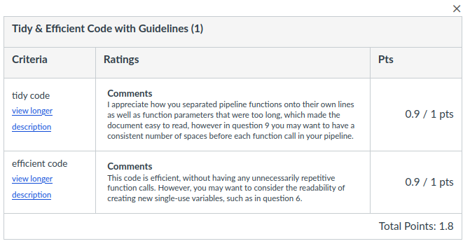